# model

MT:

##EDA

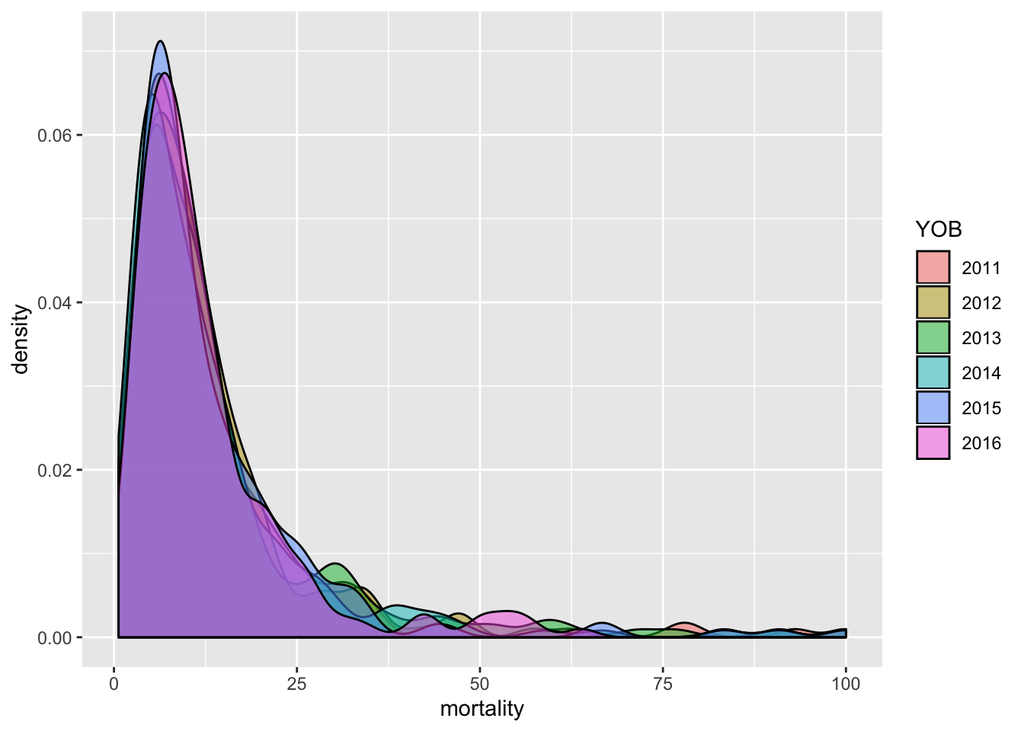

In order to determine whether it was important to allow variation by year in the model, we plotted the distribution of mortality in each year. Comparing these yearly results shows that across time, the distribution of mortality remains approximately constant. Therefore, we will not allow for account for the effect of time on mortality across all counties and races.

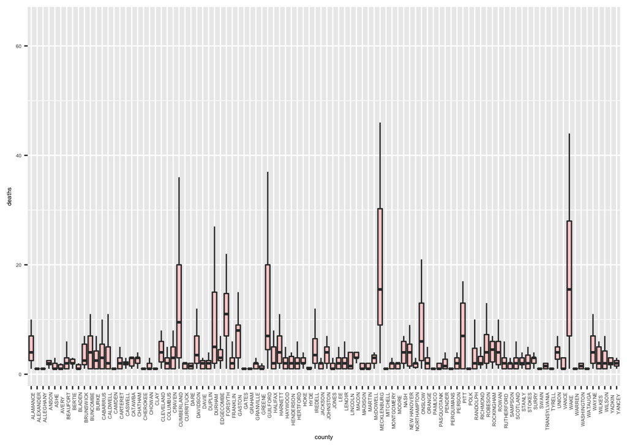

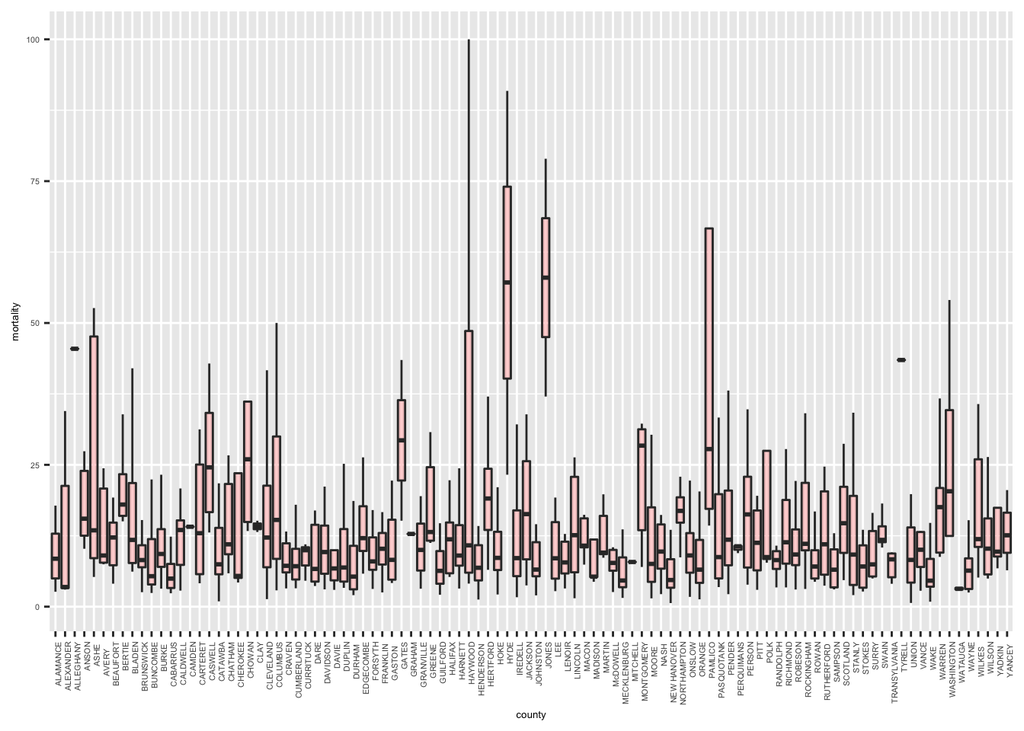

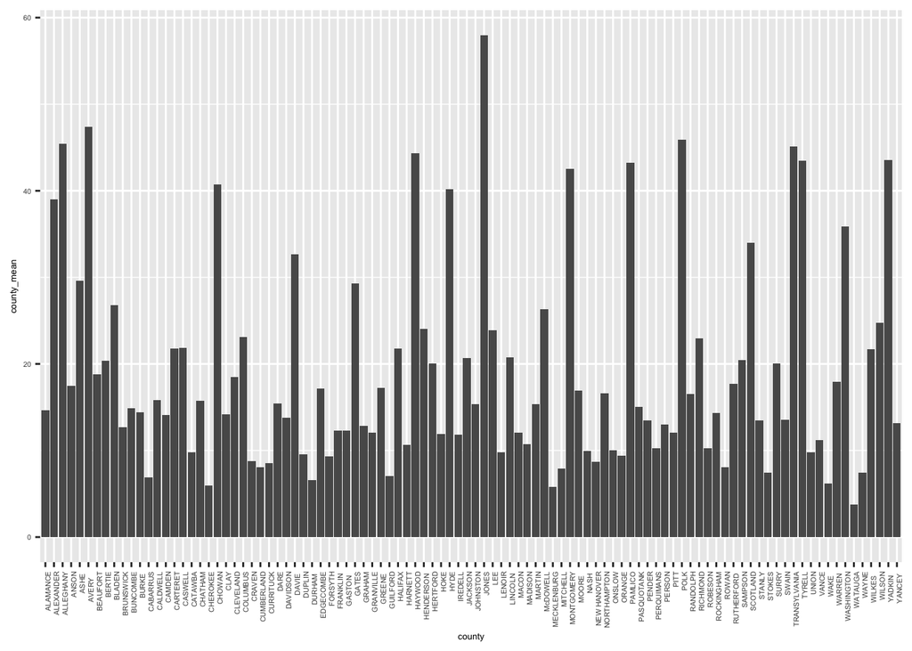

The boxplots illustrate that the absolute number of deaths and relative number of deaths convey very different information per county. This emphasises that there is a high degree of variation in mortality within each county, and across counties. Furthermore, the bar graph shows that the average mortality by county (across all races) also varies greatly. Therefore, we will allow for random effects for each county.

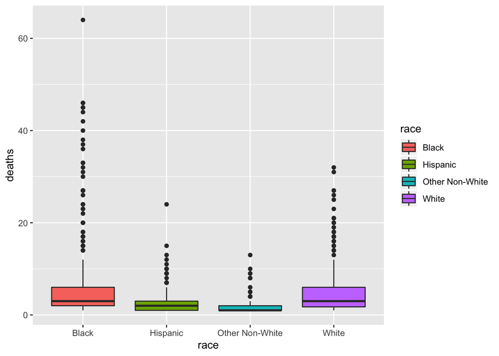

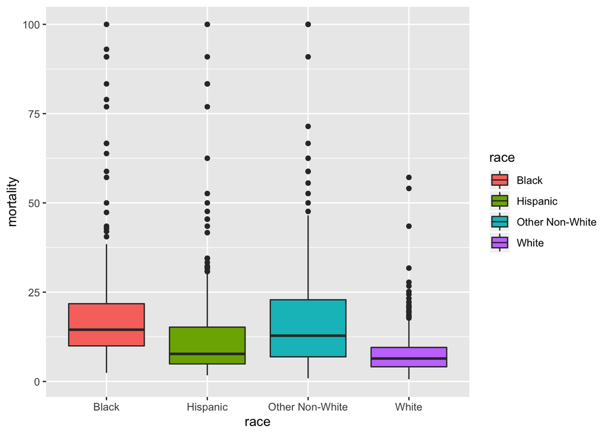

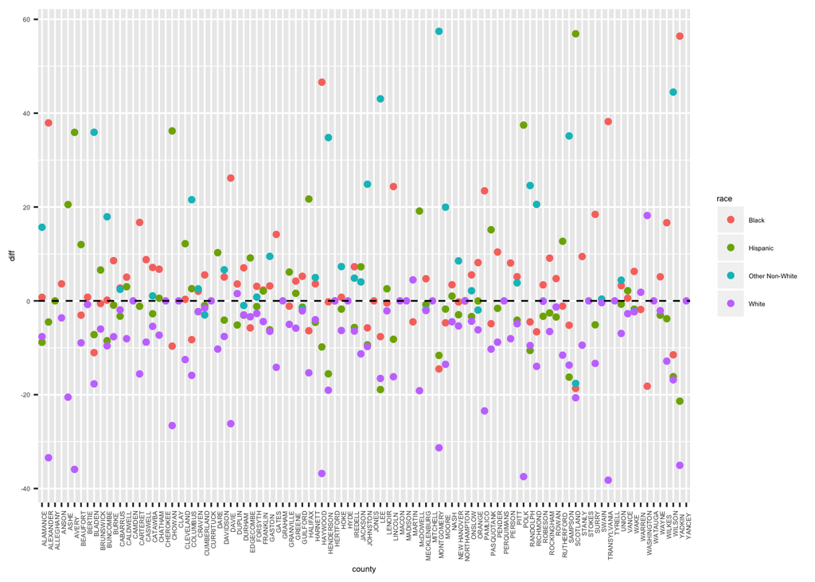

The boxplots demonstrate that the distributions of both deaths and mortality vary by race. Additonally, the scatter plot portrays the distance from the county mean for the average mortality per race in a county. This plot shows that mortality by race varies by county. Therefore, we will allow for random effects by race in our model.

##Model

```r
attach(nc)

model_deaths=lmer(deaths~(1+race|county))
summary(model_deaths)
```

```
## Linear mixed model fit by REML ['lmerMod']
## Formula: deaths ~ (1 + race | county)
##
## REML criterion at convergence: 5705.4
##
## Scaled residuals:
##     Min      1Q  Median      3Q     Max
## -3.7877 -0.4398 -0.1316  0.3004  7.7880
##
## Random effects:
##  Groups   Name                Variance Std.Dev. Corr
##  county   (Intercept)         61.995   7.874
##           raceHispanic        40.106   6.333    -1.00
##           raceOther Non-White 56.371   7.508    -0.99  0.99
##           raceWhite           22.241   4.716    -0.81  0.82  0.79
##  Residual                      4.584   2.141
## Number of obs: 1173, groups:  county, 100
##
## Fixed effects:
##             Estimate Std. Error t value
## (Intercept)   1.5148     0.1622   9.338
## convergence code: 0
## Model failed to converge with max|grad| = 0.0092952 (tol = 0.002, component 1)
```

```r
coef(model_deaths)
```

```
## $county
##               raceHispanic raceOther Non-White    raceWhite (Intercept)
## ALAMANCE      -3.427616604        -4.373747501   0.67122556   5.8704019
## ALEXANDER      0.360510076         0.323495836   0.58069977   1.0483811
## ALLEGHANY      0.666355529         0.805875755   0.38199675   0.6535419
## ANSON         -1.168808038        -1.224295479  -1.44058548   2.9212943
## ASHE           0.089675432         0.102798083   0.52514729   1.3649725
## AVERY         -0.136808981        -0.163070417  -0.27814624   1.7059402
## BEAUFORT      -0.623041289        -0.804638243   0.09666797   2.3561450
## BERTIE        -0.867818215        -0.948983143  -1.15394860   2.5445077
## BLADEN        -0.444588953        -0.601158797  -0.42569002   1.9473581
## BRUNSWICK     -0.003925200        -0.373169020   3.05314105   1.7987119
## BUNCOMBE      -1.218453769        -2.024517375   6.58738191   3.4668487
## BURKE          0.249782524         0.012211970   2.83299606   1.3857546
## CABARRUS      -2.022386672        -2.778572722   2.67407280   4.0710725
## CALDWELL      -0.068343492        -0.368150956   3.24462429   1.7372086
## CAMDEN         0.449353015         0.544845546   0.13962197   0.9424684
## CARTERET       0.085509739         0.006980907   1.58643111   1.4112372
## CASWELL       -0.381353275        -0.465699100  -0.09019727   2.0029594
## CATAWBA       -1.250303974        -1.748209441   1.50275230   3.2636350
## CHATHAM       -0.063467764        -0.401602589   1.09009545   1.9830080
## CHEROKEE       0.730845250         0.993297991   0.58687489   0.5556292
## CHOWAN        -0.723822746        -0.740335944  -1.11283017   2.3103764
## CLAY           0.414208441         0.508764760   0.07275738   0.9824467
## CLEVELAND     -2.929572831        -3.473938030  -0.89458124   5.1275635
## COLUMBUS      -1.195444031        -1.629447409  -0.57393811   2.9617485
## CRAVEN        -1.344993324        -2.014430130   2.85585243   3.2510564
## CUMBERLAND   -20.252845076       -24.477140212  -9.88491125  26.4588237
## CURRITUCK     -0.280686437        -0.446720759  -0.19831571   1.8827257
## DARE           0.023859692         0.028829931   0.01581110   1.4838178
## DAVIDSON      -1.358098111        -2.185943886   3.96756923   3.5333767
## DAVIE          0.287958241         0.273413123   0.73811862   1.2035209
## DUPLIN        -0.552418964        -0.704371662   0.86146381   2.1777552
## DURHAM       -14.750524904       -16.905944127 -12.84088885  19.0506270
## EDGECOMBE     -2.557067004        -2.876414701  -2.21929541   4.5633805
## FORSYTH      -10.816096840       -14.367875734  -2.67174432  16.3723741
## FRANKLIN      -0.950226235        -1.152164554   0.40423952   2.6625050
## GASTON        -4.638495289        -6.017952440   2.06703606   7.4117862
## GATES          0.418221346         0.421098773   0.12662315   0.9690447
## GRAHAM         0.449353015         0.544845546   0.13962197   0.9424684
```

[output cut: 50 more lines]

```
## TYRELL         0.692115248         0.837153981   0.38629029   0.6209975
## UNION         -1.914198274        -3.067536879  -0.23653401   4.5319231
## VANCE         -1.705190259        -2.046474641  -1.94689555   3.4717275
## WAKE         -26.426627433       -31.231655943  -9.92406663  35.1092888
## WARREN        -0.192262790        -0.266599247  -0.59442892   1.6997561
## WASHINGTON     0.136852949         0.122008334   0.41872390   1.3726794
## WATAUGA        0.400237566         0.477065346   0.19481973   1.0110537
## WAYNE         -4.396020728        -4.964770276  -2.38184493   6.6570799
## WILKES         0.342058879         0.068591989   3.36276372   1.3065805
## WILSON        -3.283769837        -3.882250323  -2.52453239   5.3452726
## YADKIN         0.216040506         0.140456448   1.14796303   1.3250312
## YANCEY        -0.473875688        -0.574579561  -0.14724160   2.1183848
##
## attr(,"class")
## [1] "coef.mer"
```

```r
model_mortality=lmer(mortality~(1+race|county))
summary(model_mortality)
```

```
## Linear mixed model fit by REML ['lmerMod']
## Formula: mortality ~ (1 + race | county)
##
## REML criterion at convergence: 8308.8
##
## Scaled residuals:
##     Min      1Q  Median      3Q     Max
## -3.6706 -0.5015 -0.0810  0.3497  7.5803
##
## Random effects:
##  Groups   Name                Variance Std.Dev. Corr
##  county   (Intercept)         769.32   27.737
##           raceHispanic        489.86   22.133   -0.16
##           raceOther Non-White 989.83   31.462    0.71  0.08
##           raceWhite           673.96   25.961   -0.99  0.30 -0.65
##  Residual                      41.17    6.416
## Number of obs: 1153, groups:  county, 100
##
## Fixed effects:
##             Estimate Std. Error t value
## (Intercept)   6.7232     0.3611   18.62
## convergence code: 0
## boundary (singular) fit: see ?isSingular
```

```r
coef(model_mortality)
```

```
## $county
##               raceHispanic raceOther Non-White   raceWhite (Intercept)
## ALAMANCE      -9.299201132          14.2593175  -8.8795879  15.3375989
## ALEXANDER    -36.095573230          40.8856919 -65.1323567  71.8334449
## ALLEGHANY     13.752589103          23.4926549 -18.9939750  30.2604898
## ANSON         15.385859191          21.0778123 -10.1754852  21.0773612
## ASHE          11.386608927          25.1524292 -26.1274916  37.5037675
## AVERY         17.662298109          42.3588878 -46.6276998  61.0913158
## BEAUFORT      13.618876266          11.2387933  -5.9723609  15.8359684
## BERTIE        15.154185114          20.9984887 -10.2684903  21.1338900
## BLADEN         2.982500647          44.4333226  -6.7504346  16.6487081
## BRUNSWICK      5.223490827           1.8990378  -4.3068241  12.2249920
## BUNCOMBE      -8.967689082          16.0799456  -8.7022360  15.2983932
## BURKE         -8.666526506          10.7603211 -15.5548253  22.3168175
## CABARRUS      -6.086840697          -0.3865568  -3.7545672   9.6824639
## CALDWELL      -1.376794037          10.7358735 -12.3912272  20.1567356
## CAMDEN         8.942095139          11.0886382  -4.7124794  13.7352269
## CARTERET     -16.896630370          19.4196314 -30.9249852  37.6773378
## CASWELL        3.629366783          22.6156493 -20.6491165  30.3179707
## CATAWBA       -9.772645021          -5.5927745 -11.1273231  16.6080634
## CHATHAM       -5.527368887          14.8079584 -14.7052600  22.1391198
## CHEROKEE       2.086197039          36.4227221 -62.8266096  75.3763481
## CHOWAN        40.447912013          30.5566117 -16.3224129  32.1452914
## CLAY          13.757168470          17.0595661  -7.2500205  17.5110363
## CLEVELAND      9.584741387           2.9103792 -10.0247784  19.0325046
## COLUMBUS       9.032637774          28.0838401  -5.8069611  15.7880686
## CRAVEN        -4.084299028           0.7093612  -4.3274369  10.6707665
## CUMBERLAND    -5.884187713          -7.8273849  -7.2836413  13.0609967
## CURRITUCK      3.989376008           4.9470226  -2.1023991   9.8514807
## DARE          -0.434810633           8.9077007 -17.0049939  25.0933144
## DAVIDSON      -8.730263819           2.3636983 -12.3874126  18.5223492
## DAVIE        -20.680966009          31.2307473 -47.9282826  55.6512409
## DUPLIN        -7.278349893          15.0984256  -6.0756757  12.7453367
## DURHAM       -10.062210642          -7.6740253  -8.2801275  13.4427656
## EDGECOMBE     15.876110313          16.0640354  -1.2007959  11.4084056
## FORSYTH       -3.982107066          -1.8880133  -5.8131178  12.1235539
## FRANKLIN       0.005721041           7.6211426  -7.0238483  14.5453513
## GASTON        -9.128924968           6.2757439  -9.2617989  15.3555897
## GATES          3.918389973          32.9004781 -31.0683555  41.9142371
## GRAHAM         7.406676816           9.1846439  -3.9033148  12.5312065
```

[output cut: 50 more lines]

```
## TYRELL        44.647723699          55.3653753 -23.5293268  41.7343115
## UNION         -4.893334548           0.6000556  -6.9795052  13.3374738
## VANCE          1.871526914           6.0834147  -4.1032932  11.6813378
## WAKE          -8.052975348          -8.2102115  -6.9161841  12.2997889
## WARREN        33.807682799          27.1696220  -2.5569822  16.3353525
## WASHINGTON    65.287421363          46.3820321   1.3572349  18.3144234
## WATAUGA       -8.022725694          -9.9485748   4.2279722   0.4320176
## WAYNE         -8.031649596           1.0414939  -6.6259613  12.4759616
## WILKES       -18.442637594          27.0182350 -30.3159064  37.1756999
## WILSON        -5.495990298          52.6610175  -5.4902029  14.3633246
## YADKIN       -63.888657567          63.2180571 -85.5643128  90.0716246
## YANCEY        14.479675288          17.9555102  -7.6307812  18.0776004
##
## attr(,"class")
## [1] "coef.mer"
```

MT: